# Checkpoint 3

9 de maio de 2017

## 1. Introdução

Este trabalho tem por objetivo descrever e explorar a estrutura de determinados grupos de universidades que oferecem programas de pós-graduação em Ciência da Computação no Brasil. Utilizaremos dados quantitativos que a CAPES utiliza na avaliação segundo o Comitê de Avaliação. Os dados foram coletados da Plataforma Sucupira, e incluem quantificações da produção de artigos, dissertações e teses nos últimos 4 anos para os diferentes PPGs:

Estamos interessados em analisar as seguintes variáveis para caracterizar e explorar os grupos de universidades que oferecem programa de pós-graduação em Ciência da Computação:

- **Nível:** Conceito da CAPES para um determinado programa de pós-graduação.
- **periodicos_A1:** Número de periódicos de qualis A1 publicados pelo PPG.
- **periodicos_A2:** Número de periódicos de qualis A2 publicados pelo PPG.
- **per_comaluno_A1:** Número de alunos que são autores ou co-autores de periódicos de qualis A1.
- **per_comaluno_A2:** Número de alunos que são autores ou co-autores de periódicos de qualis A2.

```r
require(GGally, quietly = TRUE)
require(reshape2, quietly = TRUE)
require(tidyverse, quietly = TRUE, warn.conflicts = FALSE)
library(ggfortify)
library(cluster)
library(ggdendro)
library(broom)
library(knitr)

dados_capes = read_csv("dados/capes-cacc.csv")

formata_label = function(l){
  # existem funções para formatar com , sendo milhar e . sendo decimal (scales::comma)
  # mas em pt_br é o contrário. essa função serve para isso
  format(l, big.mark = ".", scientific = FALSE, trim = TRUE, decimal.mark = ",")
}
```

## 2. Descrição das variáveis

### 2.1 Nível

De acordo com os gráficos, as universidade em maior parte possuem conceito 3 e 4, poucas universidade possuem conceito maior ou igual a 6.

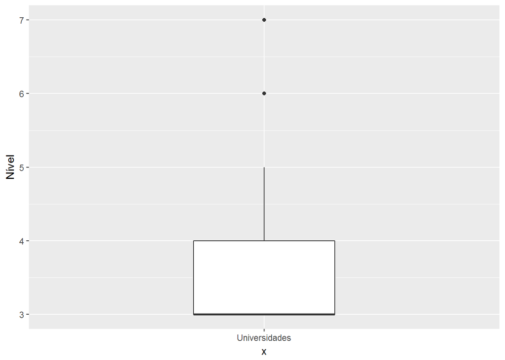

```r
dados_capes %>%
    ggplot(aes(y = `Nível`, x = "Universidades")) +
    geom_boxplot(width = .3)
```

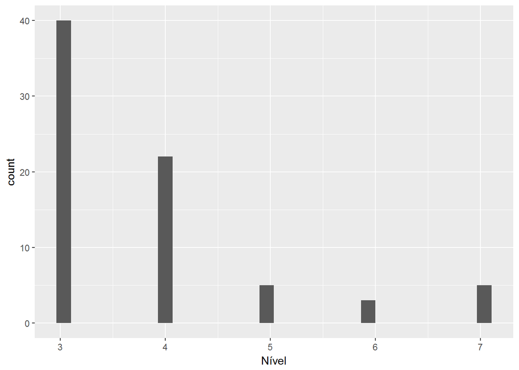

```r
dados_capes %>%
    ggplot(aes(x = `Nível`)) +
    geom_histogram(bins = 30)
```

### 2.2 periodicos_A1

De acordo com os gráficos, 15 universidades nunca publicaram um periódico em conferência de qualis A1, no entanto, a maior parte delas publicou de 1 a 25 vezes. Existem também algunas universidade que publicaram muito, ou seja, mais de 50 vezes.

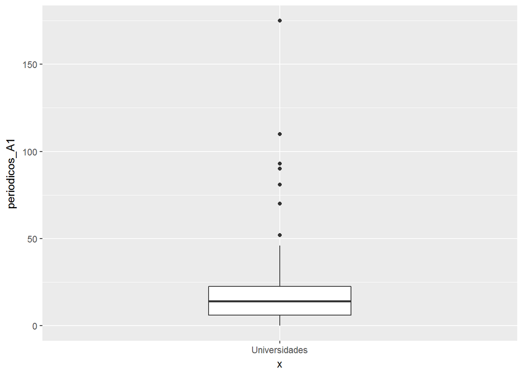

```r
dados_capes %>%
    ggplot(aes(y = periodicos_A1, x = "Universidades")) +
    geom_boxplot(width = .3)
```

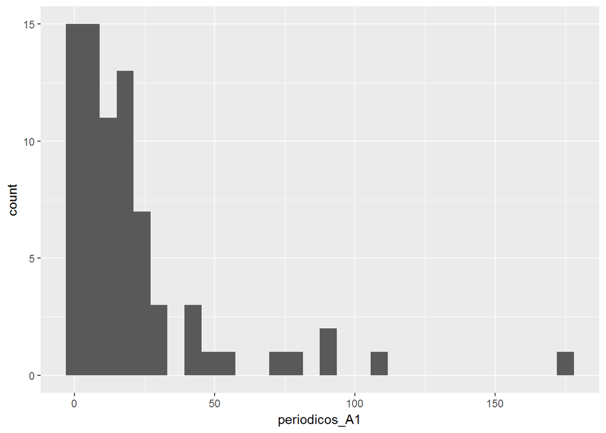

```r
dados_capes %>%
    ggplot(aes(x = periodicos_A1)) +
    geom_histogram(bins = 30)
```

### 2.3 periodicos_A2

De acordo com os gráficos, 7 universidades nunca publicaram um periódico em conferência de qualis A2, no entanto, a maior parte delas publicou de 1 a 25 vezes. Existem também algunas universidade que publicaram muito, ou seja, mais de 50 vezes, porém nenhuma publicou mais de 100 vezes.

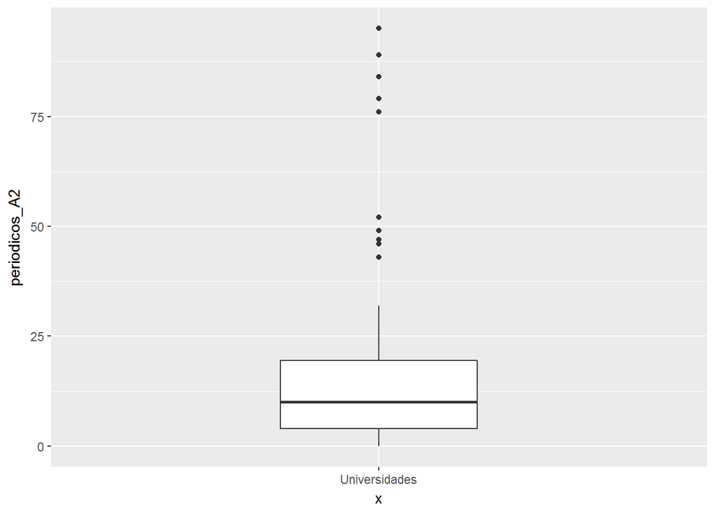

```r
dados_capes %>%
    ggplot(aes(y = periodicos_A2, x = "Universidades")) +
    geom_boxplot(width = .3)
```

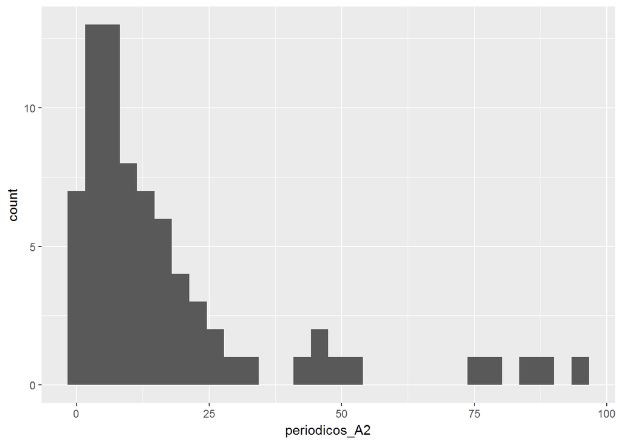

```r
dados_capes %>%
    ggplot(aes(x = periodicos_A2)) +
    geom_histogram(bins = 30)
```

### 2.4 per_comaluno_A1

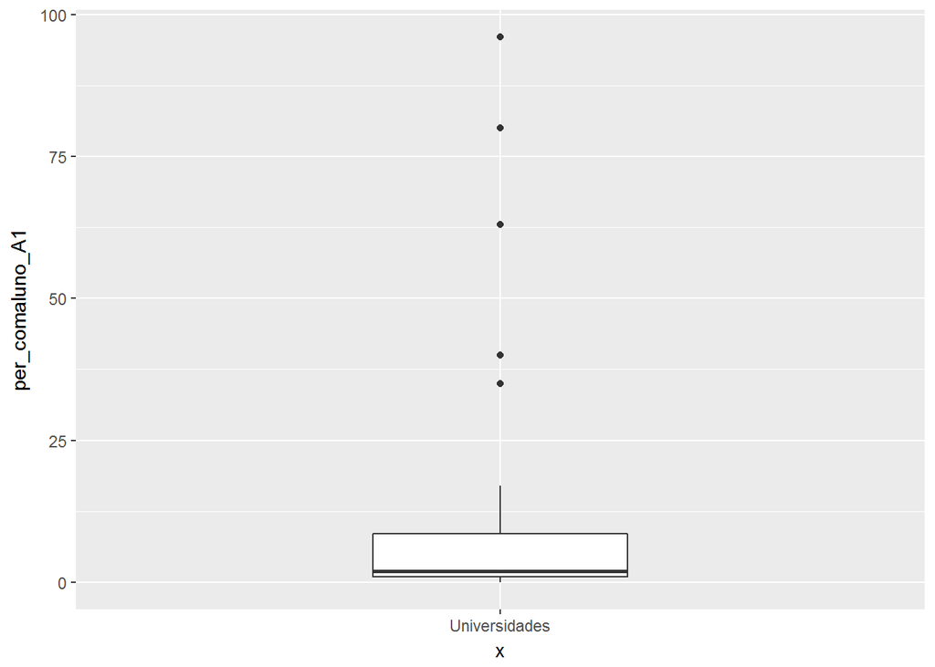

```r
dados_capes %>%
    ggplot(aes(y = per_comaluno_A1, x = "Universidades")) +
    geom_boxplot(width = .3)
```

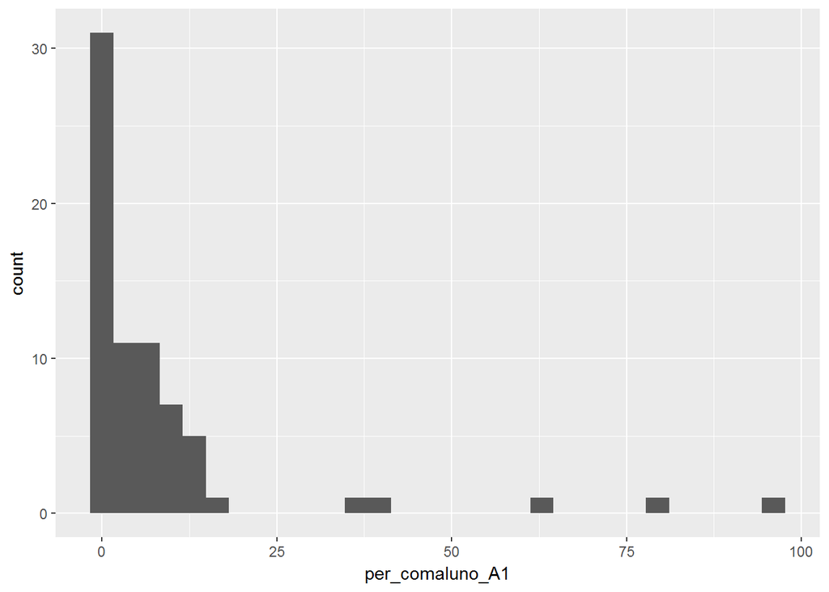

```r
dados_capes %>%
    ggplot(aes(x = per_comaluno_A1)) +
    geom_histogram(bins = 30)
```

### 2.5 per_comaluno_A2

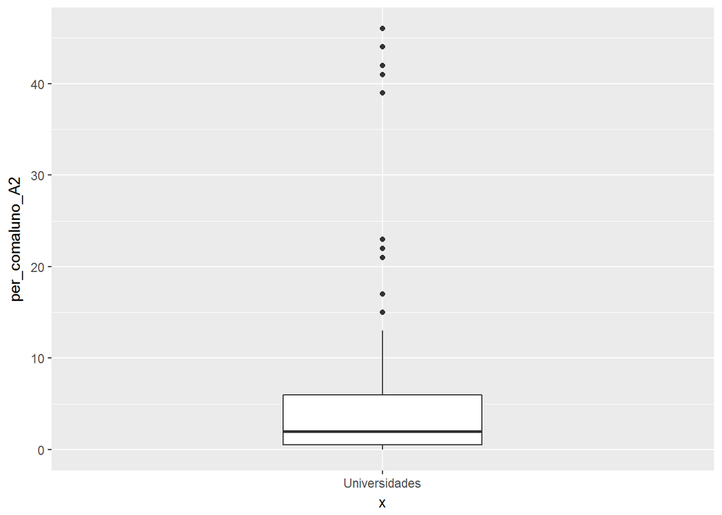

```r
dados_capes %>%
    ggplot(aes(y = per_comaluno_A2, x = "Universidades")) +
    geom_boxplot(width = .3)
```

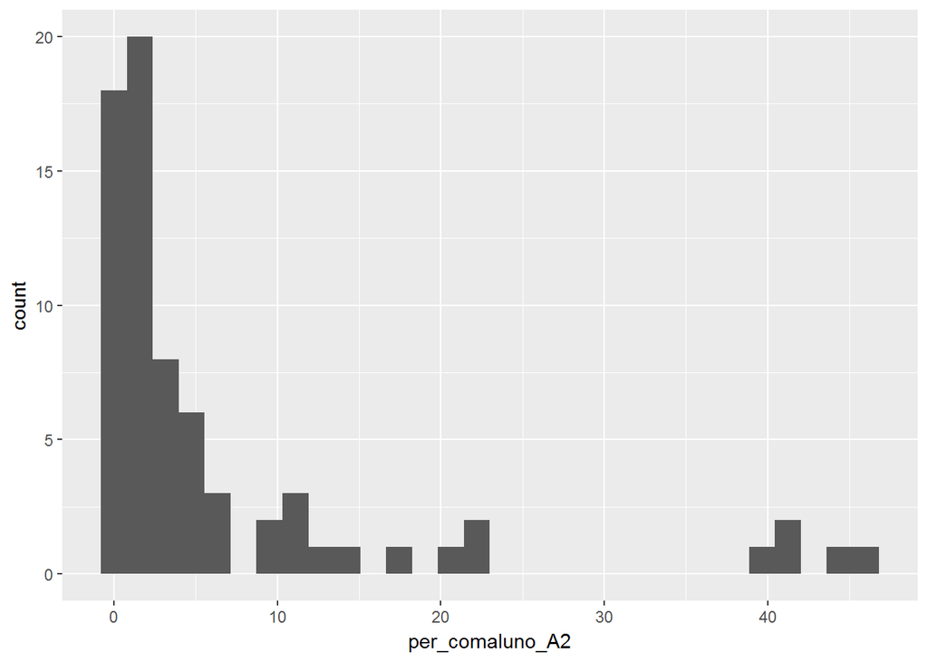

```r
dados_capes %>%
    ggplot(aes(x = per_comaluno_A2)) +
    geom_histogram(bins = 30)
```

## 3. Tratamento dos dados

Em nossos dados existiam algumas universidades com valores faltantes para as variáveis de interesse. Portanto, adotamos a medida de retirar essas universidades do nosso conjunto de observações.

```r
dados_capes = dados_capes %>%
  select(Sigla, `Nível`, periodicos_A1, periodicos_A2, per_comaluno_A1, per_comaluno_A2)

dados_capes = dados_capes %>%
  filter(complete.cases(dados_capes))

dados_capes2 = dados_capes
```

## 4. Agrupamento (kmeans)

Com intuito de identificar características, diferenças e semelhanças entre os grupos, utilizamos os seguintes gráficos para obter uma visão geral sobre o agrupamento realizado.

Usaremos o número de clusters = 5.

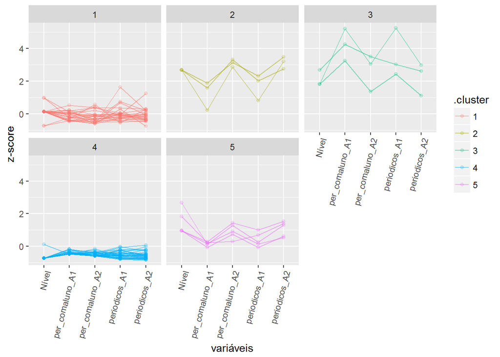

```r
n_clusters = 5

dados_capes.scaled = select(dados_capes, -Sigla) %>%
  mutate_each(funs(scale))

row.names(dados_capes.scaled)  = dados_capes$Sigla

toclust = dados_capes.scaled %>%
   rownames_to_column(var = "universidade") %>%
   select(1:6)

dists = toclust %>%
    select(-universidade) %>%
    dist()

km = toclust %>%
    select(-universidade) %>%
    kmeans(centers = n_clusters, nstart = 20)

km %>%
  augment(toclust) %>%
  gather(key = "variáveis", value = "z-score", -universidade,  -.cluster) %>%
  ggplot(aes(x = `variáveis`, y = `z-score`, group = universidade, colour = .cluster)) +
  geom_point(alpha = 0.2) +
  geom_line(alpha = .5) +
  facet_wrap(~ .cluster) +
  theme(axis.text.x = element_text(angle = 75, hjust = 1))
```

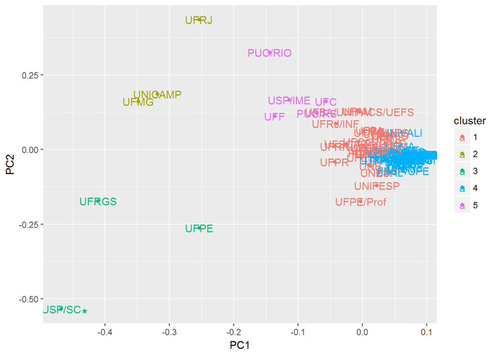

```r
autoplot(km, data = dados_capes.scaled, label = TRUE)
```

Os gráficos apresentados destacam os aspectos principais que caracterizam cada grupo, ou seja, podemos ver quais são as variáveis que se destacam. Além disso, é possível perceber que todos os grupos são distintos, no entanto, alguns possuem certa semelhança, por exemplo os grupos 1 e 4.

### 4.1 Classificação dos grupos

Diante dos gráficos resultantes do agrupamento podemos nomear os grupos e citar algumas universidades que fazem parte deles.

- **Grupo 1:** Universidades de baixa produtividade de periódicos de qualis A1 e A2 com baixa participação de alunos e com conceito na média nacional.
- **Grupo 2:** Universidades de alta produtividade de periódicos de qualis A2 com boa participação de alunos e com conceito acima da média nacional.
- **Grupo 3:** Universidades de alta produtividade de periódicos de qualis A1 e A2 com boa particação de alunos e com conceito acima da média nacional.
- **Grupo 4:** Universidades de baixa produtividade de periódicos de qualis A1 e A2 com baixa particação de alunos e com conceito abaixo da média nacional.
- **Grupo 5:** Universidades de razoável produtividade de periódicos de qualis A2 com boa participação de alunos e com conceito acima da média nacional.

### 4.2 Avaliação do Agrupamento

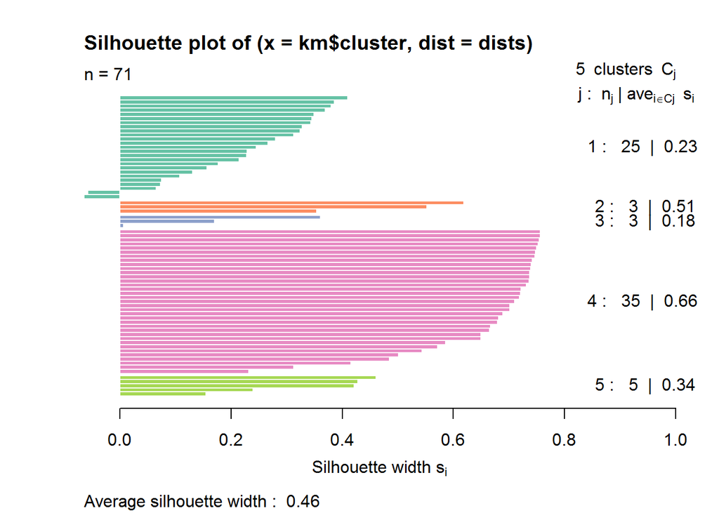

```r
plot(silhouette(km$cluster, dists), col = RColorBrewer::brewer.pal(n_clusters, "Set2"))
```

## 5. PCA

Análise de componentes principais (PCA) é uma técnica usada para enfatizar a variação e trazer padrões fortes em um conjunto de dados. É freqüentemente usado para tornar os dados fáceis de explorar e visualizar. Inicialmente, iremos executar o PCA em nossos dados com scale = TRUE para que sejam feitas as normalizações, evitando o impacto de discrepâncias dos valores nas variâncias. Em seguida, encontraremos e veremos os componentes e sua relação com as variáveis originais.

```r
row.names(dados_capes) = dados_capes$Sigla

pr.out = prcomp(select(dados_capes, -Sigla), scale = TRUE)

kable(pr.out$rotation)
```

|  | PC1 | PC2 | PC3 | PC4 | PC5 |
| --- | --- | --- | --- | --- | --- |
| Nível | -0.4347159 | 0.5099626 | -0.6930796 | -0.2615099 | -0.0470473 |
| periodicos_A1 | -0.4440346 | -0.4911381 | 0.1711152 | -0.5978993 | -0.4181540 |
| periodicos_A2 | -0.4596024 | 0.3130537 | 0.5456541 | -0.1797119 | 0.6006066 |
| per_comaluno_A1 | -0.4327571 | -0.5891404 | -0.3470069 | 0.4154445 | 0.4154840 |
| per_comaluno_A2 | -0.4640499 | 0.2315869 | 0.2687157 | 0.6076500 | -0.5381251 |

Utilizamos a função plot_pve para analisarmos quanta variância cada PC captura, observamos que os dois primeiros componentes explicam cerca de 95% da variância.

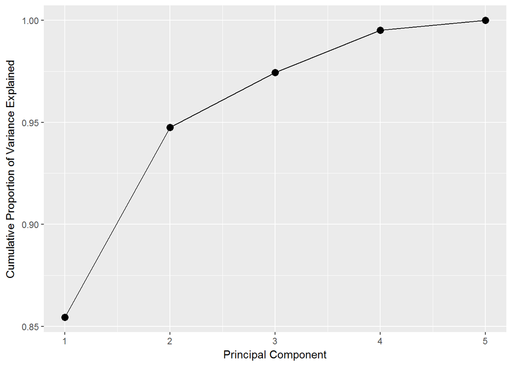

```r
# Porcentagem da variância explicada:
plot_pve <- function(prout){
  pr.var <- pr.out$sdev^2
  pve <- pr.var / sum(pr.var)
  df = data.frame(x = 1:NROW(pve), y = cumsum(pve))
  ggplot(df, aes(x = x, y = y)) +
    geom_point(size = 3) +
    geom_line() +
    labs(x='Principal Component', y = 'Cumulative Proportion of Variance Explained')
}

plot_pve(pr.out)
```

O gráfico a seguir mostra a estrutura dos grupos formados pela execução do PCA. Podemos percerber que algumas universidades se encontram aglomeradas em algumas regiões, outras já se mantém muito isoladas como a USP/SC, UFRGS, UFPE e UFRJ.

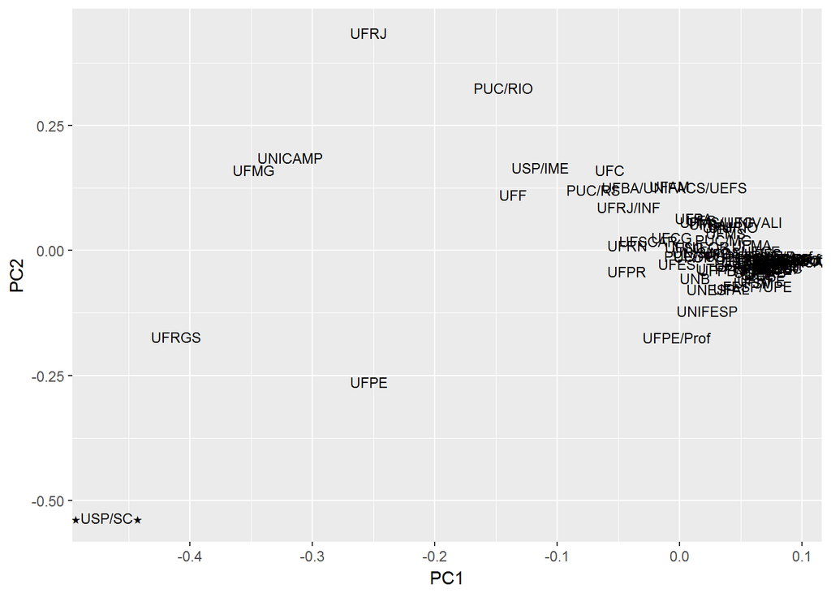

```r
autoplot(pr.out, label = TRUE, label.size = 3, shape = FALSE)
```

Quando aplicamos os vetores de direcionamento com suas respectivas variáveis, conseguimos entender os comportamentos existentes nos dados. Podemos observar que as universidades que mais publicam em periódicos com qualis A1 e A2, e que possuem maior número de alunos entre os autores, são tambem as universidades que possuem melhor conceito (nível) da CAPES no seu programa de pós-graduação. No entanto, esse não é o único critério para definição do conceito, por exemplo, a USP/SC possui 175 publicações em periódicos de qualis A1 e 84 de qualis A2, porém, seu conceito é 6, que é menor que o conceito da UFRJ (conceito 7) que posssui 48 periódicos de qualis A1 e 89 de qualis A2. As universidades que se mantiveram mais aglomeradas são as que possuem menor quantidade de periódicos A1 e A2, consequentemente, também são as que possuem menor conceito pela CAPES. Existe uma co-relação forte entre os números de publicações em periódicos e o número de alunos que tiveram seu nome entre os autores nesses periódicos, no entanto, tal comportamento já era obviamente esperado.

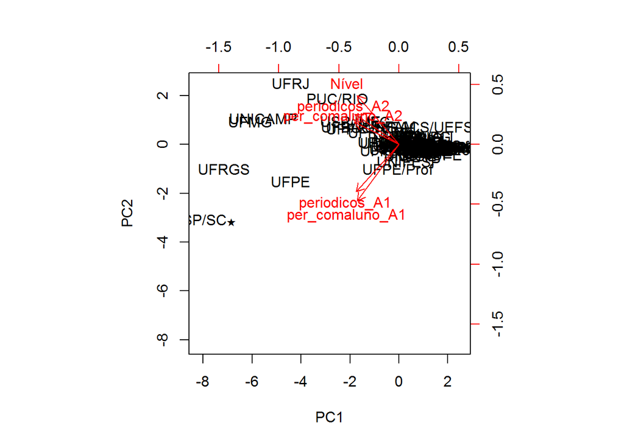

```r
biplot(pr.out, scale = 0)
```

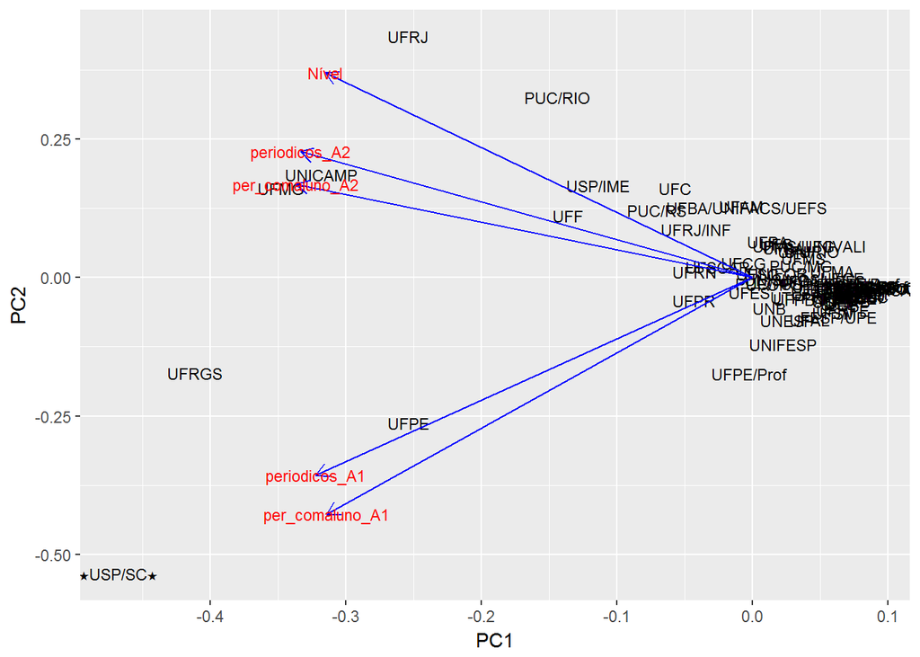

```r
autoplot(pr.out, label = TRUE, label.size = 3, shape = FALSE,
         loadings = TRUE, loadings.colour = 'blue',
         loadings.label = TRUE, loadings.label.size = 3)
```

## 6. t-SNE

```r
require(Rtsne)

tsne.out = Rtsne(dados_capes2,
                 verbose = TRUE,
                 perplexity = 5)
```

```
## Read the 71 x 50 data matrix successfully!
## Using no_dims = 2, perplexity = 5.000000, and theta = 0.500000
## Computing input similarities...
## Normalizing input...
## Building tree...
##  - point 0 of 71
## Done in 0.00 seconds (sparsity = 0.290419)!
## Learning embedding...
## Iteration 50: error is 64.681401 (50 iterations in 0.01 seconds)
## Iteration 100: error is 64.456901 (50 iterations in 0.01 seconds)
## Iteration 150: error is 60.663549 (50 iterations in 0.01 seconds)
## Iteration 200: error is 60.206727 (50 iterations in 0.01 seconds)
## Iteration 250: error is 58.077616 (50 iterations in 0.01 seconds)
## Iteration 300: error is 1.582589 (50 iterations in 0.01 seconds)
## Iteration 350: error is 0.875910 (50 iterations in 0.01 seconds)
## Iteration 400: error is 0.312887 (50 iterations in 0.01 seconds)
## Iteration 450: error is 0.281969 (50 iterations in 0.01 seconds)
## Iteration 500: error is 0.279984 (50 iterations in 0.01 seconds)
## Iteration 550: error is 0.270431 (50 iterations in 0.01 seconds)
## Iteration 600: error is 0.262629 (50 iterations in 0.01 seconds)
## Iteration 650: error is 0.258089 (50 iterations in 0.01 seconds)
## Iteration 700: error is 0.253305 (50 iterations in 0.01 seconds)
## Iteration 750: error is 0.257404 (50 iterations in 0.01 seconds)
## Iteration 800: error is 0.253491 (50 iterations in 0.01 seconds)
## Iteration 850: error is 0.249428 (50 iterations in 0.01 seconds)
## Iteration 900: error is 0.250092 (50 iterations in 0.01 seconds)
## Iteration 950: error is 0.247810 (50 iterations in 0.01 seconds)
## Iteration 1000: error is 0.249337 (50 iterations in 0.01 seconds)
## Fitting performed in 0.23 seconds.
```

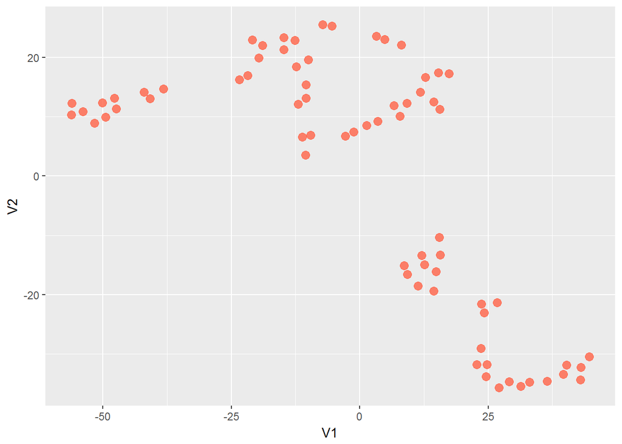

```r
df = as.data.frame(tsne.out$Y)
df$Sigla = dados_capes2$Sigla

ggplot(df, aes(x = V1, y = V2, label = Sigla)) +
  geom_point(alpha = 0.8, size = 3, color = "tomato")
```

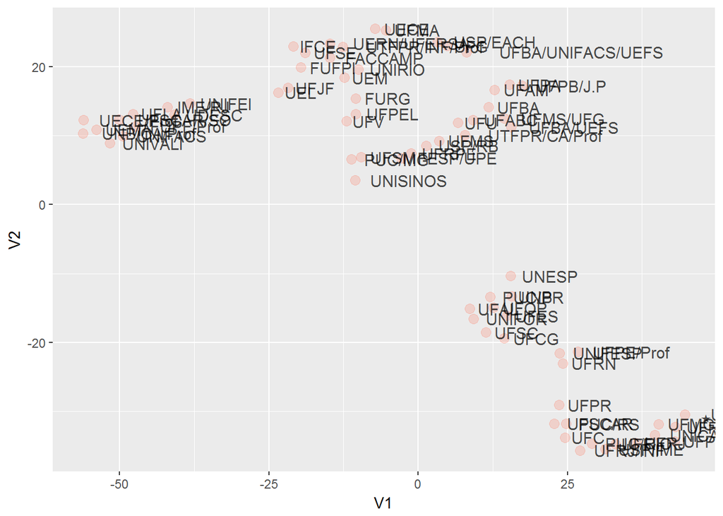

```r
ggplot(df, aes(x = V1, y = V2, label = Sigla)) +
  geom_point(alpha = 0.2, size = 3, color = "tomato") +
  geom_text(alpha = .7, size = 4, hjust = -.2)
```